# Exploratory Analysis

## Introductory Paragarph

The overarching theme for this analysis is health. While in the midst of a pandemic, it’s crucial to understand how to effectively maintain one’s health and analyzing trends in health data sets can help individuals with this. These data sets provides insight into both physical and mental health as well as other health topics. The data sets chosen focus on health related factors such as mental health, Covid/diet, and heart disease. These data sets can be utilized in order to answer questions such as is there correlations between age and cholesterol levels. In this case, the graphs created were primarily derived from the heart data set.

## Summary Paragraph

The data set we are working with has 12 columns/observations that show different health characteristics and 918 rows/features/participants. The average and median age is both around 54 years old. However, there are more males than females within this data set with for every male there is about 4 males as seen with `$male_female_ratio`. Out of the 918 rows/participahnts, 508 participants have a health disease (`$heart_disease_count`) and 371 have exercise angina also known as chest pain during exercise (`$exercise_angina_count`). We wanted to dive deeper into both the heart disease and exercise angina groups so we also calculated the basic health characteristics such as age, cholesterol, and resting blood pressure.

```
## $obs_heart
## [1] 12
##
## $feat_heart
## [1] 918
##
## $avg_age
## [1] 53.51089
##
## $med_age
## [1] 54
##
## $male_female_ratio
## [1] 3.756477
##
## $heart_disease_count
## [1] 508
##
## $heart_disease_avg_age
## [1] 55.89961
##
## $heart_disease_avg_cholest
## [1] 175.9409
##
## $heart_disease_avg_rest_BP
## [1] 134.185
##
## $exercise_angina_count
## [1] 371
##
## $exercise_angina_avg_age
## [1] 55.98113
##
## $exercise_angina_avg_cholest
## [1] 194.2642
##
## $exercise_angina_avg_rest_BP
## [1] 135.8814
```

## Aggregated Table and Observations

We included this table to show the difference in health characteristics of those of the same age and those who currently have and don’t have a heart disease. The table is arranged by age and grouped to those who have or don’t have a heart disease which is seen in the `HeartDisease` column where 0 represents the group without a current heart disease and 1 representing those who do. The next few columns show the average resting blood pressure (`Avg_RestingBP`), average cholesterol (`Avg_Cholesterol`), and average maximum heart rate (`Avg_Max_HR`). We averaged and grouped these columns to show the difference in these health characteristics so that we can see how those of the same age but with different heart conditions differ. From this we found that depending on the age, these characteristics are all lower or higher, or some characteristics are lower or higher. From this, we can choose a specific age range to help predict heart disease based on these characteristics.

```
## # A tibble: 93 × 5
## # Groups:   Age [49]
##      Age HeartDisease Avg_RestingBP Avg_Cholesterol Avg_Max_HR
##    <int>        <int>         <dbl>           <dbl>      <dbl>
##  1    28            0          130             132        185
##  2    29            0          130             237.       177.
##  3    30            0          170             237        170
##  4    31            0          100             219        150
##  5    31            1          120             270        153
##  6    32            0          113.            226.       168
##  7    32            1          118             529        130
##  8    33            0          120             298        185
##  9    33            1          100             246        150
## 10    34            0          123.            197.       175.
## # … with 83 more rows
```

## Charts

### Chart 1

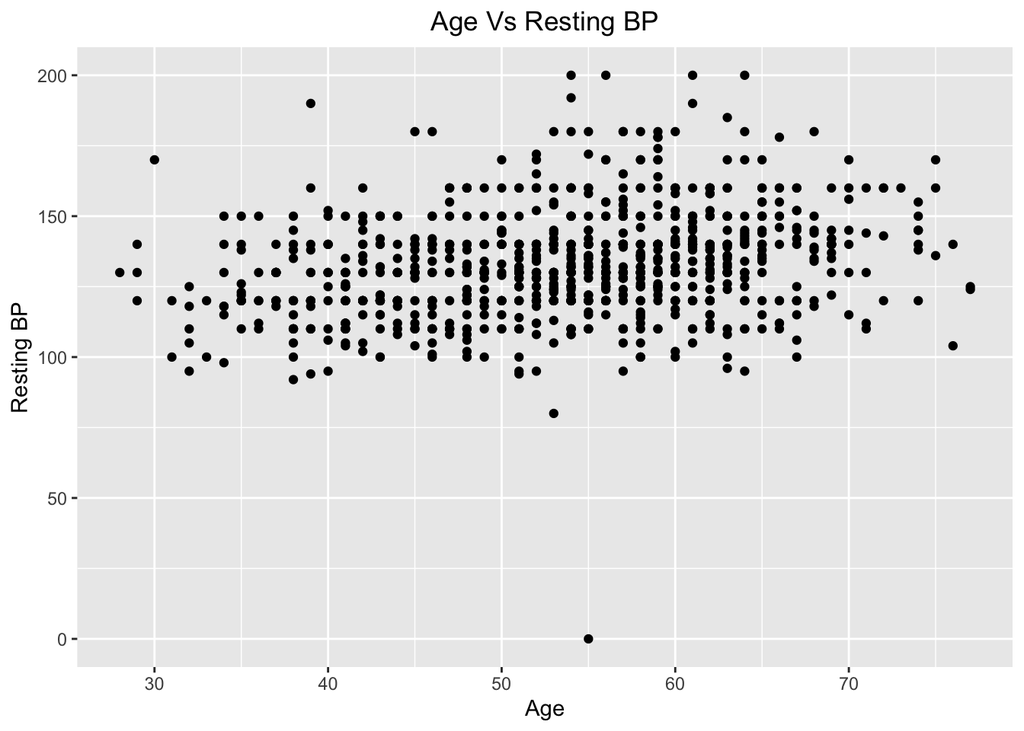

### Chart 2

The line graph show the comparison of cholesterol level compared to the resting blood pressure. The purpose of this chart is too is identify the correlation of cholesterol and resting blood pressure. For this data set we found that cholesterol did not have a big correlation with resting blood pressure. Using the line chart we can see as the cholesterol changed the resting blood pressure stayed pretty consistent. The resting blood pressure ranged from about 100 - 200 but did not not depend on the cholesterol level of the patient.

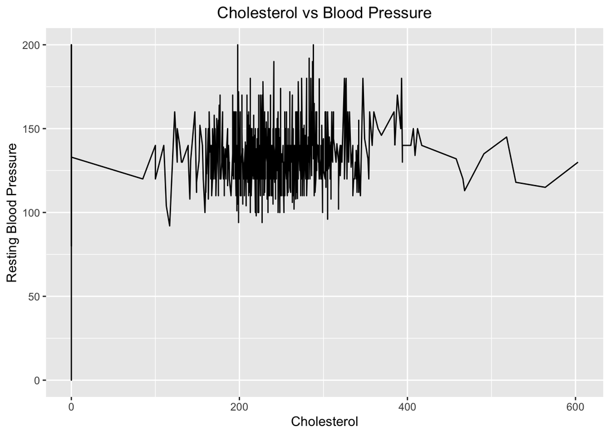